# Guided Project: Analyzing Movie Ratings

# Introduction

- Our goal: we want to extract data from the top 30 movies between March and July 2020. We can extract various details, including a movie’s title, description, actors, director, genre, runtime, and ratings.
- Then, we want to check whether ratings correlate to user votes. For instance, do the highest-rated movies also have the highest user vote scores?

#Loading the Web Page

# Instructions

Load the rvest, dplyr, and ggplot2 packages. Specify the URL where we’ll extract video data. To avoid external server instability issues, use this link, which is a copy of the study page on our servers. Load the web page content using the read_html() function. Save the result as wp_content. We’ll use this variable throughout the project.

```r
library(dplyr)
library(rvest)
library(xml2)
library(ggplot2)
```

```r
url <- "http://dataquestio.github.io/web-scraping-pages/IMDb-DQgp.html"
wp_content <- read_html(url)
```

# String Manipulation

The content we extract from web pages is often text (character), so knowing how to manipulate strings is crucial. This screen provides a few important things to keep in mind.

Converting a number as a string into numeric using the as.numeric() function. as.numeric(“125”) # it yields 125 as numeric as.numeric(c(“5.14”, “2.84”)) # it yields 5.14 2.84 as numeric as.numeric(“1,025”) # it yields NA instead of 1025

Parsing a string containing a number into numeric using the readr::parse_number() function. The command as.numeric(“1,025”) yields NA because the number 1,025 contains a comma (,), a non-numeric character. To troubleshoot this issue, we can use the readr::parse_number() function. It drops any non-numeric characters and returns the number

readr::parse_number(“1,025”) # it yields 1025 as numeric readr::parse_number(c(“3km”, “40 mins”, “(+2.5)”)) # it yields 3.0 40.0 2.5 as numeric

Removing the whitespaces from start and end of string using the stringr::str_trim() function.

stringr::str_trim(" Remove whitespaces before and after “) # it yields”Remove whitespaces before and after"

Instructions

Convert “10.50” into numeric. Convert the vector c(“14.59”, “3.14”, “55”) into numeric. Parse the vector c(“14 min”, “17,35”, “(2012)”, “1,2,3,4”) into numeric. Remove whitespaces at the beginning and end of " Spaces before and after should disappear ".

```r
parse_number("10.50")
```

```
[1] 10.5
```

```r
as.numeric(c("14.59", "3.14", "55"))
```

```
[1] 14.59  3.14 55.00
```

```r
parse_number(c("14 min", "17,35", "(2012)", "1,2,3,4"))
```

```
[1]   14 1735 2012 1234
```

```r
str_trim(" Spaces before and after should disappear    ")
```

```
[1] "Spaces before and after should disappear"
```

#Extracting Elements from Header

data <- content %>% html_nodes(the_selector) %>% html_text()

Instructions

Extract the movies’ titles.

Find the title CSS selector, and assign the result to a variable. Identify the number of elements this selector will select from Selector Gadget. Extract the movie titles, combining the html_nodes() and html_text() functions. Print the titles vector. Extract the movies’ years.

Use a process similar to the one we used to extract the titles. The year values are wrapped in parentheses that we want to eliminate, and then we want to convert the values from character to numeric data type. Print the years vector. Compare the number of elements from Selector Gadget with the length of the output vector.

They should be the same.

```r
print(titles)
```

```
 [1] "Mulan"
 [2] "The Call"
 [3] "Greenland"
 [4] "Don't Listen"
 [5] "Unhinged"
 [6] "Ava"
 [7] "The Hunt"
 [8] "Ghosts of War"
 [9] "Hamilton"
[10] "The Old Guard"
[11] "The Secret: Dare to Dream"
[12] "The Outpost"
[13] "Extraction"
[14] "Train to Busan Presents: Peninsula"
[15] "Greyhound"
[16] "The King of Staten Island"
[17] "A Quiet Place Part II"
[18] "Bloodshot"
[19] "The Dark and the Wicked"
[20] "Arkansas"
[21] "The Rental"
[22] "Trolls World Tour"
[23] "Sputnik"
[24] "Eurovision Song Contest: The Story of Fire Saga"
[25] "Inheritance"
[26] "Spenser Confidential"
[27] "The Tax Collector"
[28] "The Way Back"
[29] "The Silencing"
[30] "Archive"
```

```r
NROW(year)
```

```
[1] 30
```

# Extracting the Movies’ Features

When you find the selector, here’s the basic code snippet to extract the desired information

data <- content %>% html_nodes(the_selector) %>% html_text() Instructions

Extract the movies’ runtimes.

Find the runtime CSS selector, and assign the result to a variable. Identify the number of elements this selector will select from Selector Gadget. Extract the movie runtimes, combining the html_nodes() and html_text() functions. Convert the runtimes from character to numeric data type because they end with “min” (for minute). Print the runtimes vector. Extract the movies’ genres.

Extract the genres using a similar process as before. Remove whitespaces at the end of genre characters. Print the genres vector.

```r
runtimes <- wp_content %>%
  html_nodes(".runtime") %>%
  html_text()
runtimes <- parse_number(runtimes)
print(runtimes)
```

```
 [1] 115 112 119  97  90  96  90  94 160 125 107 123 116 116  91 136  97 109  95 117  88
[22]  90 113 123 111 111  95 108  93 109
```

```r
 genres <- wp_content %>%
  html_nodes(".genre ") %>%
  html_text()
genres <- str_trim(genres)
print(genres)
```

```
 [1] "Action, Adventure, Drama"     "Horror, Mystery, Thriller"
 [3] "Action, Drama, Thriller"      "Drama, Horror, Thriller"
 [5] "Action, Thriller"             "Action, Crime, Drama"
 [7] "Action, Horror, Thriller"     "Horror, Thriller, War"
 [9] "Biography, Drama, History"    "Action, Adventure, Fantasy"
[11] "Drama, Romance"               "Action, Drama, History"
[13] "Action, Thriller"             "Action, Horror, Thriller"
[15] "Action, Drama, History"       "Comedy, Drama"
[17] "Drama, Horror, Sci-Fi"        "Action, Drama, Sci-Fi"
[19] "Horror"                       "Crime, Drama, Thriller"
[21] "Horror, Thriller"             "Animation, Adventure, Comedy"
[23] "Drama, Horror, Sci-Fi"        "Comedy, Music"
[25] "Drama, Mystery, Thriller"     "Action, Comedy, Crime"
[27] "Action, Crime, Drama"         "Drama, Sport"
[29] "Action, Crime, Thriller"      "Drama, Sci-Fi, Thriller"
```

#Extracting the Movies’ Ratings

When you find the selector, here’s the basic code snippet to extract the desired information.

data <- content %>% html_nodes(the_selector) %>% html_attr(attribute_name) Instructions

Extract the movies’ user ratings.

Find the use rating CSS selector and assign the result to a variable. Identify the number of elements this selector will select from Selector Gadget. Extract the user ratings, combining the html_nodes() and html_attr() functions. Convert the user ratings from character to numeric data type. Print the user ratings vector. Extract the movies’ metascores.

Extract the movie metascore using a similar process as before. Remove whitespaces at the end of metascores and convert them into numeric data type. Print the metascores vector. Compare the number of elements from Selector Gadget with the length of the output vector.

They should be the same.

```r
NROW(ratings)
```

```
[1] 29
```

```r
NROW(metascores)
```

```
[1] 25
```

# Extracting the Movie’s Vote

When you find the selector, here’s the basic code snippet to extract the desired information

data <- content %>% html_nodes(the_selector) %>% html_text()

Instructions

Extract the movies’ votes.

Find the vote CSS selector, and assign the result to a variable. Identify the number of elements this selector will select from Selector Gadget. Extract the votes, combining the html_nodes() and html_text() functions. Convert the votes from character to numeric data type. Print the votes vector. Compare the number of elements from Selector Gadget with the length of the output vector.

They should be the same.

```r
votes <- wp_content %>%
  html_nodes(".sort-num_votes-visible") %>%
  html_text()
votes <- parse_number(votes)
print(votes)
```

```
 [1]  80231   6559  27482   4879  25316  20882  62277   4886  48663 117211   5420  17001
[13] 151319  16815  60885  29278  57763   3701   7951  13965  14792  10516  69186   7837
[25]  65768   7416  28300   9355   9271
```

```r
NROW(votes)
```

```
[1] 29
```

#Dealing with Missing Values

We’ve extracted the titles, years, runtimes, genres, user ratings, metascores, and votes from our web page. We can now combine them using the tibble() function. Since we’re missing some data, this operation will throw an error.

Exploring the web page again, we notice that the 17th movie is partly the cause of this problem. Furthermore, movies 2, 3, 4, 17, and 29 don’t have metascores.

To solve these problems, we’ll do the following: - We can introduce NA as missing values and deal with them later if necessary. - We can also remove missing positions from other vectors to get vectors of the same length.

In our case, we’ll do the following: - Introduce NA values in the metascores vector. - Remove the 17th element from all the vectors with a length of 30.

Inserting values into a vector is not a trivial operation, so it isn’t available in R. We’ve provided you with the append_vector() function.

```r
append_vector <- function(vector, inserted_indices, values){

  ## Creating the current indices of the vector
  vector_current_indices <- 1:length(vector)

  ## Adding small amount of values (between 0 and 0.9) to the `inserted_indices`
  new_inserted_indices <- inserted_indices + seq(0, 0.9, length.out = length(inserted_indices))

  ## Appending the `new_inserted_indices` to the current vector indices
  indices <- c(vector_current_indices, new_inserted_indices)

  ## Ordering the indices
  ordered_indices <- order(indices)

  ## Appending the new value to the existing vector
  new_vector <- c(vector, values)

  ## Ordering the new vector wrt the ordered indices
  new_vector[ordered_indices]
}
```

Suppose we have a letters vector spanning from A to J where D and H are missing. We can use the append_vector() custom function to either insert NA or the missing values.

```r
# Inserting NA
append_vector(vector, c(3, 6), NA)
```

```
 [1] "A" "B" "C" NA  "E" "F" "G" NA  "I" "J"
```

You might see that we indicated the position after which to insert the item. We can also specify several positions and values.

Suppose now we have the same letters vector from A to J where D, E, and H are missing. We can still use the append_vector() custom function to either insert NA or the missing values

```r
vector <- c("A", "B", "C", "F", "G", "I", "J") # D, E and H are missing

# Inserting NA
append_vector(vector, c(3, 3, 5), NA)
```

```
 [1] "A" "B" "C" NA  NA  "F" "G" NA  "I" "J"
```

```r
# Inserting D and H
append_vector(vector, c(3, 3, 5), c("D", "E", "H"))
```

```
 [1] "A" "B" "C" "D" "E" "F" "G" "H" "I" "J"
```

You might see that we indicated the same position for consecutive insertions. We can also specify several positions and values.

Accordingly, to insert NA into the metascores vector at positions 2, 3, 4, 17, and 29, we have to provide the following positions to our function: 1, 1, 1, 13, and 24. They are the positions after which to insert NA.

Instructions

Copy-paste the append_vector() in your markdown file or your project script.

Use the append_vector() function to insert NA into the metascores vector after the positions 1, 1, 1, 13, and 24.

Save the result back in metascores vector. Remove the 17th element from the vectors: titles, years, runtimes, genres, and metascores.

Save the result back to these vectors.

```r
NROW(ratings)
```

```
[1] 29
```

# Putting it all together

Instructions

Create a dataframe with the data we previously extracted: titles, years, runtimes, genres, user ratings, metascores, and votes.

| titles | years | runtimes | genres | metascores | ratings | votes |
| --- | --- | --- | --- | --- | --- | --- |
| Mulan | 2020 | 115 | Action, Adventure, Drama | 66 | 5.5 | 80231 |
| The Call | 2020 | 112 | Horror, Mystery, Thriller | NA | 7.2 | 6559 |
| Greenland | 2020 | 119 | Action, Drama, Thriller | NA | 6.3 | 27482 |
| Don't Listen | 2020 | 97 | Drama, Horror, Thriller | NA | 6.1 | 4879 |
| Unhinged | 2020 | 90 | Action, Thriller | 40 | 6.0 | 25316 |
| Ava | 2020 | 96 | Action, Crime, Drama | 39 | 5.3 | 20882 |
| The Hunt | 2020 | 90 | Action, Horror, Thriller | 50 | 6.5 | 62277 |
| Ghosts of War | 2020 | 94 | Horror, Thriller, War | 38 | 5.5 | 4886 |
| Hamilton | 2020 | 160 | Biography, Drama, History | 90 | 8.6 | 48663 |
| The Old Guard | 2020 | 125 | Action, Adventure, Fantasy | 70 | 6.6 | 117211 |

[output cut: 19 more lines]

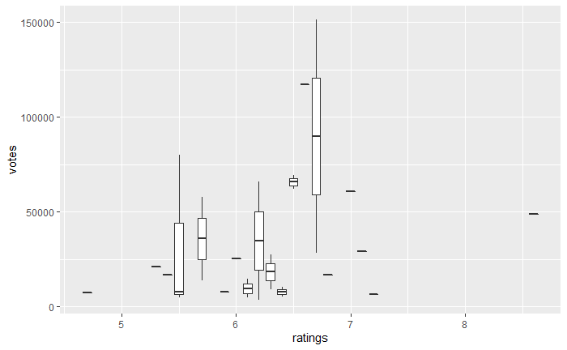